# COMPSCIX 415.2 Homework 5/Midterm

Quynh Tran

February 27, 2018

# https://github.com/mightyquynh/compscix-415-2-assignments

# The tidyverse packages (3 points)

```r
library(tidyverse)
```

## 1) Can you name which package is associated with each task below?

### Plotting: ggplot2

### Data munging/wrangling - dplyr

### Reshaping (speading and gathering) data - dplyr

### Importing/exporting data - readr

## 2) Now can you name two functions that you’ve used from each package that you listed above for these tasks?

### Plotting - geom_boxplot() geom_line()

### Data munging/wrangling - filter() select()

### Reshaping data - spread() gather()

### Importing/exporting data (note that readRDS and saveRDS are base R functions) - read_delim() write_csvc()

# R Basics (1.5 points)

## 1) Fix this code with the fewest number of changes possible so it works. My_data.name___is.too0ooLong <- c( 1 , 2 , 3 ) Just removing ! will make it work, although the data name is very bad:

```r
My_data.name___is.too0ooLong <- c( 1 , 2   , 3 )

My_data.name___is.too0ooLong
```

```
## [1] 1 2 3
```

## 2) Fix this code so it works. c has to be small cap, and it was missing a closing ’.

```r
y_string <- c('has', 'an', 'error', 'in', 'it')

y_string
```

```
## [1] "has"   "an"    "error" "in"    "it"
```

```r
my_vector <- c(1, 2, '3', '4', 5)
my_vector
```

```
## [1] "1" "2" "3" "4" "5"
```

# Data import/export

```r
file_path <- '~/compscix-415-2-assignments/rail_trail.txt'
rail_trail <- read_delim(delim = '|', file = file_path)
glimpse(rail_trail)
```

```
## Observations: 90
## Variables: 10
## $ hightemp   <int> 83, 73, 74, 95, 44, 69, 66, 66, 80, 79, 78, 65, 41,...
## $ lowtemp    <int> 50, 49, 52, 61, 52, 54, 39, 38, 55, 45, 55, 48, 49,...
## $ avgtemp    <dbl> 66.5, 61.0, 63.0, 78.0, 48.0, 61.5, 52.5, 52.0, 67....
## $ spring     <int> 0, 0, 1, 0, 1, 1, 1, 1, 0, 0, 0, 1, 1, 0, 0, 1, 0, ...
## $ summer     <int> 1, 1, 0, 1, 0, 0, 0, 0, 1, 1, 1, 0, 0, 0, 0, 0, 1, ...
## $ fall       <int> 0, 0, 0, 0, 0, 0, 0, 0, 0, 0, 0, 0, 0, 1, 1, 0, 0, ...
## $ cloudcover <dbl> 7.6, 6.3, 7.5, 2.6, 10.0, 6.6, 2.4, 0.0, 3.8, 4.1, ...
## $ precip     <dbl> 0.00, 0.29, 0.32, 0.00, 0.14, 0.02, 0.00, 0.00, 0.0...
## $ volume     <int> 501, 419, 397, 385, 200, 375, 417, 629, 533, 547, 4...
## $ weekday    <int> 1, 1, 1, 0, 1, 1, 1, 0, 0, 1, 1, 1, 1, 1, 1, 1, 0, ...
```

```r
saveRDS(rail_trail, file = "~/compscix-415-2-assignments/rail_trail.rds")

rail_trail<- readRDS(file ='~/compscix-415-2-assignments/rail_trail.rds')

glimpse(rail_trail)
```

```
## Observations: 90
## Variables: 10
## $ hightemp   <int> 83, 73, 74, 95, 44, 69, 66, 66, 80, 79, 78, 65, 41,...
## $ lowtemp    <int> 50, 49, 52, 61, 52, 54, 39, 38, 55, 45, 55, 48, 49,...
## $ avgtemp    <dbl> 66.5, 61.0, 63.0, 78.0, 48.0, 61.5, 52.5, 52.0, 67....
## $ spring     <int> 0, 0, 1, 0, 1, 1, 1, 1, 0, 0, 0, 1, 1, 0, 0, 1, 0, ...
## $ summer     <int> 1, 1, 0, 1, 0, 0, 0, 0, 1, 1, 1, 0, 0, 0, 0, 0, 1, ...
## $ fall       <int> 0, 0, 0, 0, 0, 0, 0, 0, 0, 0, 0, 0, 0, 1, 1, 0, 0, ...
## $ cloudcover <dbl> 7.6, 6.3, 7.5, 2.6, 10.0, 6.6, 2.4, 0.0, 3.8, 4.1, ...
## $ precip     <dbl> 0.00, 0.29, 0.32, 0.00, 0.14, 0.02, 0.00, 0.00, 0.0...
## $ volume     <int> 501, 419, 397, 385, 200, 375, 417, 629, 533, 547, 4...
## $ weekday    <int> 1, 1, 1, 0, 1, 1, 1, 0, 0, 1, 1, 1, 1, 1, 1, 1, 0, ...
```

# Visualization

## 1) The Mrs. President pie charts would be better as bar charts One problem is that the yes/no sum don’t total 100%, so in that case, I would just present the “yes” response. It should also be 2 separate graphics, age is a different variable from gender.

```r
president <- tribble(
  ~age,     ~yes, ~no,
  "1under45",  79, 16,
  "2b45-64",    69, 22,
  "365over",   44, 39
)

president
```

```
## # A tibble: 3 x 3
##   age        yes    no
##   <chr>    <dbl> <dbl>
## 1 1under45  79.0  16.0
## 2 2b45-64   69.0  22.0
## 3 365over   44.0  39.0
```

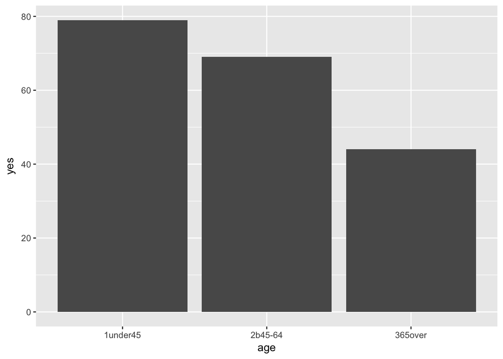

```r
ggplot(data=president)+
  geom_bar(mapping=aes(x=age, y=yes), stat = "identity")
```